# Case Study 2: Reducing Gun Deaths

Alice Pao

May 14, 2022

```r
library(tidyverse)
library(gghighlight)
dat <- read_csv('https://raw.githubusercontent.com/fivethirtyeight/guns-data/master/full_data.csv')
```

### Background

You are working for a client who wants to create a marketing campaign that helps reduce gun deaths in the US. The client would like to identify several target audiences that could benefit from such a campaign, as well identify any seasonal trends in gun deaths in these target audiences.

### Introduction

This project, we dived into the causes and different demographics of gun shot deaths. We also determined the two main target audiences: 15-29 years old male and female high school students.

### Graph Insights

The first graph shows that the majority of gun deaths victims are male. The largest gun deaths group is caused by suicide. The second largest gun deaths group is a result of homicide. Only a small portion of women died from gun usage.

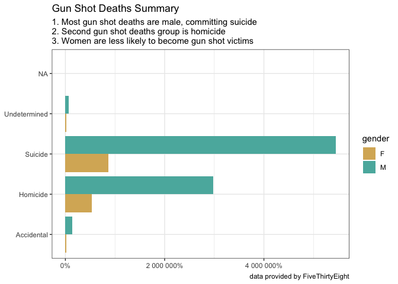

```r
dat %>%
  ggplot()+
  geom_bar(aes(x=intent, fill=sex), position="dodge")+
  scale_y_continuous(labels=scales::percent)+
  scale_fill_manual(values = c("#d8b365", "#5ab4ac"))+
  coord_flip()+
  labs(
    title = "Gun Shot Deaths Summary",
    subtitle = "1. Most gun shot deaths are male, committing suicide \n2. Second gun shot deaths group is homicide \n3. Women are less likely to become gun shot victims",
    y= "porportion",
    fill= "gender",
    caption = "data provided by FiveThirtyEight"
  )+
  theme(plot.title = element_text(hjust = 0.5), plot.subtitle = element_text(hjust = 0.5))+
  theme_bw()+
  theme(axis.title.x = element_blank(),
        axis.title.y = element_blank())
```

The second graph shows that most homicide male deaths are young men aging 15-29.

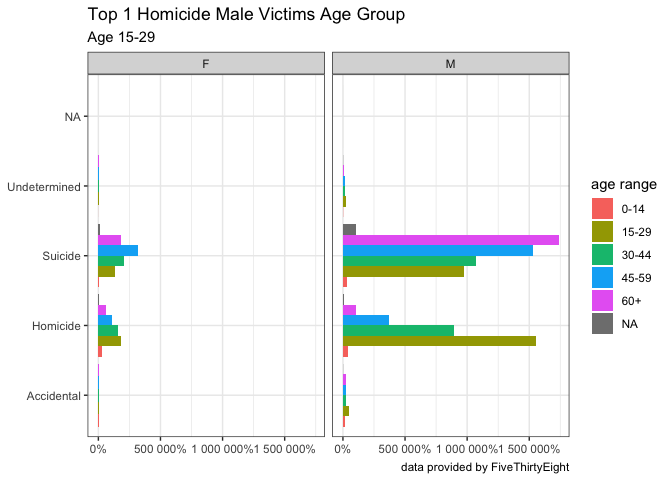

```r
age_dat <- dat %>%
  mutate(age_range = case_when(age > 60 ~ '60+', age >=45 & age <=59 ~ '45-59', age>=30 & age <=44 ~ '30-44', age>=15 & age<=29 ~ '15-29', age>=0 & age<=14 ~ '0-14'))
age_dat %>%
  ggplot(aes(x=intent, fill=age_range))+
  geom_bar(position="dodge")+
  scale_fill_hue(c = 40)+
  scale_y_continuous(labels=scales::percent)+
  scale_fill_discrete(name = "age range")+
  facet_wrap(.~sex)+
  labs(
    title = "Top 1 Homicide Male Victims Age Group",
    subtitle = "Age 15-29",
    caption = "data provided by FiveThirtyEight",
    x= "intents",
    y= "porportion"
  )+
  coord_flip()+
  theme(plot.title = element_text(hjust = 0.5), plot.subtitle = element_text(hjust = 0.5))+
  theme_bw()+
  theme(axis.title.x = element_blank(),
        axis.title.y = element_blank())
```